# R basics

# Reviewing some R basics

In this section, we will review the RStudio/POSIT software usage, and the R basics.

## RStudio

What is RStudio?

- Free and open source IDE (Integrated Development Environment) for R
- Available for Windows, Mac OS and LINUX

[figure not shown]

### Panels

When you open RStudio, you will see 3-4 panels:

- top-left: scripts and files
- bottom-left: R console Linux-line terminal / command-line
- top-right: environment, history, connections, tutorial
- bottom-right: tree of folders and files, plots/graphs window, packages, help window, viewer, presentation

[figure not shown]

### Shortcuts

RStudio provides a variety of [shortcuts](https://docs.posit.co/ide/user/ide/reference/shortcuts.html) to make user interaction smoother.

From the software, click {kbd}`Alt` + {kbd}`Shift` + {kbd}`K` to display all available shortcuts.

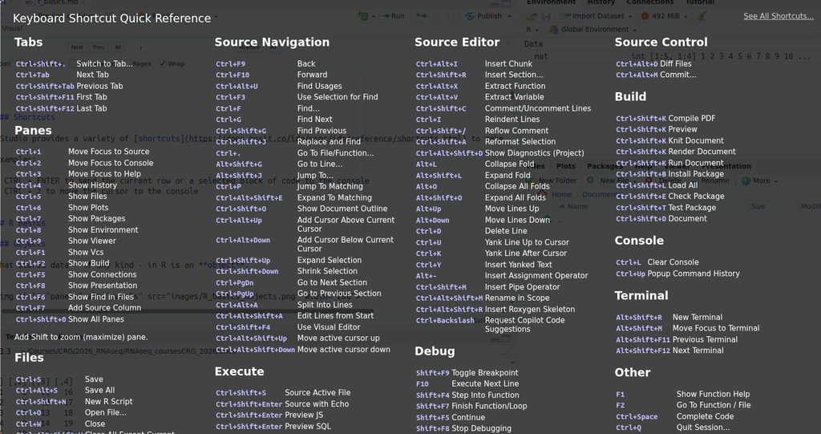

Examples:

- {kbd}`CTRL` + {kbd}`ENTER` to send the current row or a selected block of code to the console
- {kbd}`CTRL` + {kbd}`2` to move the cursor to the console

## R Basics

### Objects

What stores data - if any kind - in R is an **object**.

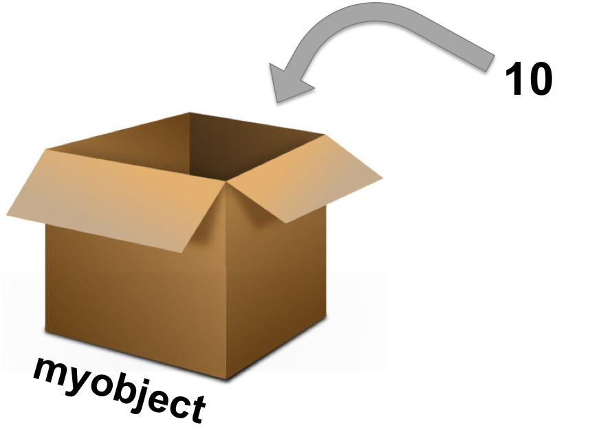

Assignment operators (how to assign data to the object)

- **<-** or **=**
- Mostly the same but, to avoid confusions:
  - Use **<-** for assignments
  - Keep **=** for functions arguments

Assigning a value to the object **B**:

```r
B <- 10
```

Reassigning: modifying the content of an object:

```r
B + 10
```

**B unchanged !!**

```r
B <- B + 10
```

**B changed !!**

You can see the objects you created in the **environment** panel (upper right).

Note: Naming an object in R is flexible. You should nevertheless follow a few base rules:

- You can use:
  - Letters (note that object names case sensitive: A and a are NOT the same)
  - Numbers (exception: the object name cannot start with a number)
  - Underscores _
- You cannot use:
  - Spaces
  - Most special characters

### Data types and data structures

#### Data types

Each object has a data type: * Numeric (number - integer or double) * Character (text) * Logical (TRUE / FALSE) * Factors (categorical variables)

Numeric: numbers, floats

```r
number_object <- 10
mode(number_object)
typeof(number_object)
str(number_object)
```

Character: text, strings of characters

```r
text_object <- "word"
mode(text_object)
typeof(text_object)
str(text_object)
```

Logical: boolean values (TRUE or FALSE)

```r
logical_object <- TRUE
mode(logical_object)
typeof(logical_object)
str(logical_object)
```

Factor: used to work with categorical variables, for example, in statistical modeling or graphing.

Creating a factor starts by creating an object, that is then converted to a factor.

```r
factor_object <- factor(text_object)
mode(factor_object)
typeof(factor_object)
str(factor_object)
```

#### Data structures

The main data structures in R are:

- Vector
- Matrix
- Data frame
- List

##### Vectors

Vectors are one-dimensional and contain a single data type.

Create a numeric vector:

```r
a <- c(1, 2, 3, 4, 5)
# equivalent to:
a <- 1:5
```

Create a second numeric vector, and check with elements of that second vector are also present in **a** with operator **%in%**:

```r
b <- 3:8

b[b %in% a]
```

Check the length of (i.e. number of elements in) a vector:

```r
length(b)
```

##### Matrices

Matrices are two-dimensional and contain a single data type.

Create a matrix:

```r
# specify number of rows
mat <- matrix(1:20, nrow=4)

# specify number of columns
mat <- matrix(1:20, ncol=4)
```

Check dimensions (i.e. number of rows and number of columns) of a matrix:

```r
# Number of rows
nrow(mat)

# Number of columns
ncol(mat)

# Dimensions (first element is the number of rows, second element is the number of columns)
dim(mat)
```

You can extract rows and columns of a matrix using the slicing operator **[]** and their position/index:

```r
# first row
mat[1,]

# row 1 and 3
mat[c(1,3),]

# first column
mat[,1]

# column 2 and 3
mat[,c(2, 3)] # or mat[,2:3]
```

##### Data frames

Data frames are two-dimensional and can contain several data types (column-wise).

Create a data frame:

```r
df <- data.frame(Name=c("Maria", "Juan", "Alba", "Enrique"),
        Age=c(23, 25, 31, 28),
        Vegetarian=c(TRUE, TRUE, FALSE, FALSE))
```

Check dimensions (i.e. number of rows and number of columns) of a dataframe:

```r
# Number of rows
nrow(df)

# Number of columns
ncol(df)

# Dimensions (first element is the number of rows, second element is the number of columns)
dim(df)
```

You can extract columns of a data frame with:

- Slicing operator **[]**
  - Access using the column name: `df[,"Age"]`
  - Access using the column index (i.e. position): `df[,2]`
- Dollar sign **$**: `df$Age`

You can extract rows - as with matrices - using the slicing operator: df[1,]

Select rows of the data frame **if the Age column is superior to 24**:

```r
d[d$Age > 24,]
```

Select rows of the data frame based on multiple conditions, for example, **if the Age column is superior to 24 AND if Vegetarian is TRUE** :

```r
d[d$Age > 24 & d$Vegetarian == TRUE,]
```

Table of logical operators that can be used for data selection and filtering:

| Operator | Description |
| --- | --- |
| < | less than |
| <= | less than or equal to |
| > | greater than |
| >= | greater than or equal to |
| == | exactly equal to |
| != | not equal to |
| !x | not x |
| x\|y | x OR y |
| x&y | x AND y |

## Paths and directories

Show the path of the current directory (i.e. working directory) with **getwd** (get working directory):

```r
getwd()
```

Change working directory with **setwd** (set working directory)

Go to a directory giving the absolute path (note: **~** is a shortcut to your home directory):

```r
setwd("~/rnaseq_course")
```

Go to a directory using the relative path:

```r
setwd("differential_expression")
```

You are now in: “~/rnaseq_course/differential_expression”  
Move one directory “up” the tree:

```r
setwd("..")
```

You are now in: “~/rnaseq_course”

## Missing values

**NA** (Not Available) is a recognized element in R.

Finding missing values in a vector:

```r
# Create vector
x <- c(4, 2, 7, NA)

# Find missing values in vector:
is.na(x)

# Remove missing values
na.omit(x)
x[ !is.na(x) ]
```

Some functions can deal with NAs, either by default, or with specific parameters:

```r
x <- c(4, 2, 7, NA)

# default arguments
mean(x)

# set na.rm=TRUE for the mean function to work properly
mean(x, na.rm=TRUE)
```

In a matrix or a data frame, you can keep only rows where there are no NA values:

```r
# Create matrix with some NA values
mydata <- matrix(c(1:10, NA, 12:2, NA, 15:20, NA), ncol=3)

# Keep only rows without NAs
mydata[complete.cases(mydata), ]
# or
na.omit(mydata)
```

Check this [R blogger post on missing/null values](https://www.r-bloggers.com/r-null-values-null-na-nan-inf/)

## Read in, write out

### On vectors

Read a file as a vector using **scan**:

```r
# Read in file
scan(file="file.txt")
# Save in  object
k <- scan(file="file.txt")
```

By default, the function scans for “double” (numeric) elements: it fails if the input contains characters.

If reading non-numeric data, you need to specify the type of data contained in the file:

```r
# specify the type of data to scan
scan(file="file.txt",
        what="character")
scan(file="~/file.txt",
        what="character")
```

If the file is not in the current directory, you can provide a full or relative path.

For example, if the file is located in the home directory, read it as:

```r
scan(file="~/file.txt",
        what="character")
```

Write the content of a vector in a file with **write**:

```r
# create a vector
mygenes <- c("SMAD4", "DKK1", "ASXL3", "ERG", "CKLF", "TIAM1", "VHL", "BTD", "EMP1", "MALL", "PAX3")

# write in a file
write(x=mygenes,
        file="gene_list.txt")
```

Like when reading a file, you can also specify a full or relative path where to write down a file:

```r
# Write to home directory
write(x=mygenes,
        file="~/gene_list.txt")

# Write to one directory up
write(x=mygenes,
        file="../gene_list.txt")
```

### Data frames or matrices

Read in a file as a data frame with **read.table**:

```r
a <- read.table(file="file.txt")
```

You can convert it as a matrix, if needed, with:

```r
a <- as.matrix(read.table(file="file.txt"))
```

Write a data frame or matrix to a file with **write.table**:

```r
write.table(x=a,
        file="file.txt")
```

Useful arguments:

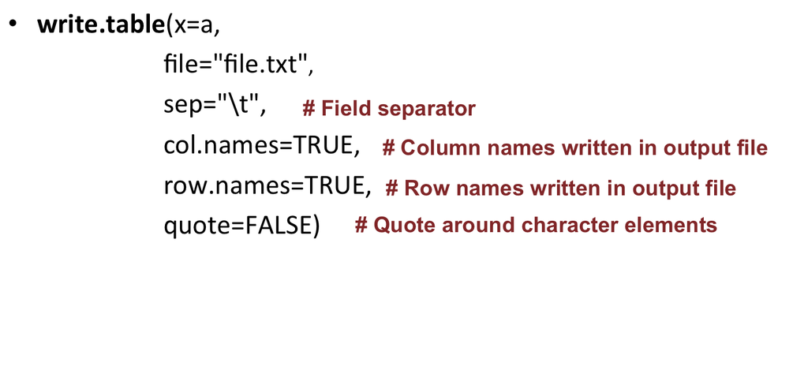